# WISAR6

Fitting a flu forecaster to the score it’s judged by

Thomas Robacker

Reich Lab · UMass Amherst

2026-11-02

# Where WISAR6 lives

## The one-sentence pitch

Most Bayesian models weight parameter values by a **likelihood**: prior × likelihood gives the posterior, which we sample rather than maximize.

WISAR6 swaps the likelihood for **the forecast score we’re graded on**: parameters that score better under WIS get more posterior weight.

1. Context: FluSight and UMass-flusion
2. The idea: Bayesian updating with a scoring rule instead of a likelihood
3. The model: priors, software, sampler
4. Forecasts: how it compares with other UMass models

## What we forecast

- **FluSight:** weekly flu hospital admissions (NHSN) (CDC NHSN 2025)
- 53 locations (US, 50 states, DC, PR)
- 0–3 weeks ahead
- A forecast is a **distribution**, reported as 23 quantiles

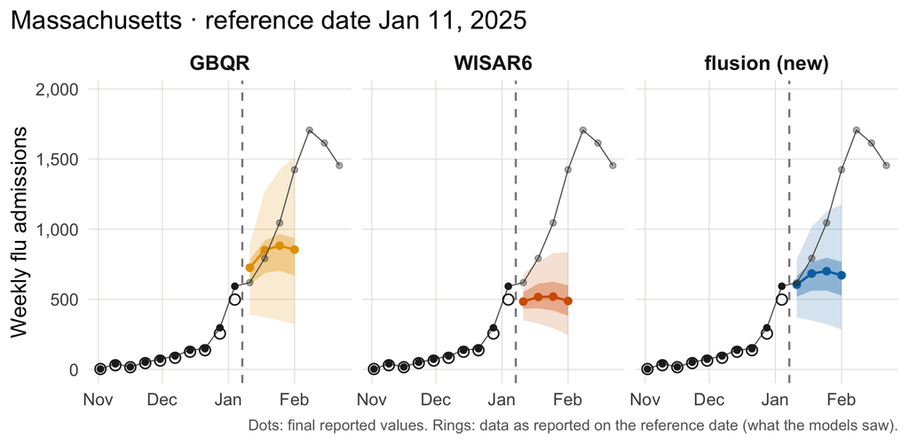

Bands: 50% and 90% intervals; line: median. Black points were observed when the forecast was made; grey points came later (h = 0 is the not-yet-reported current week). Dashed line: data cutoff.

Quantile levels: 0.01, 0.025, 0.05, 0.10, 0.15, …, 0.90, 0.95, 0.975, 0.99 (every 0.05 from 0.05 to 0.95, plus the four tail levels)

## UMass-flusion is an ensemble

- **Ensemble** = average several models’ forecasts, quantile by quantile
- Different model families make different mistakes, so averaging tends to cancel some of them
- UMass-flusion (Ray et al. 2024) pairs:
  - **GBQR**: gradient-boosted quantile regression on several surveillance sources (machine learning)
  - an **AR model**: a statistical time-series model of the hospitalization curve

**2024/25 recipe:** equal-weight average of

- GBQR (NHSN + FluSurv-NET + ILINet)
- AR(6), pooled across locations

The AR slot is where WISAR6 comes in.

## How forecasts are graded: WIS

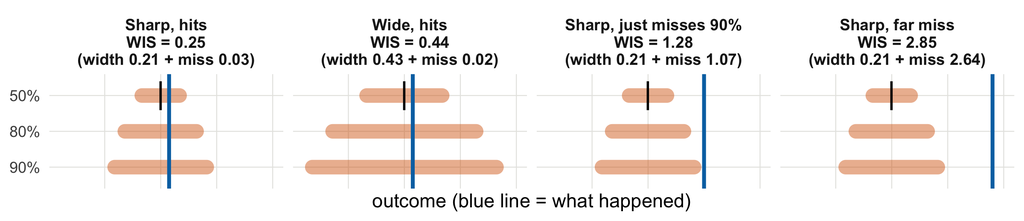

$$\text{WIS} = \frac{1}{K+\tfrac12}\Big(\tfrac12\,|y-m| \;+\; \sum_{k=1}^{K}\tfrac{\alpha_k}{2}\,\Big[\underbrace{(u_k-l_k)}_{\text{width}} \;+\; \underbrace{\tfrac{2}{\alpha_k}\,\text{dist}(y,[l_k,u_k])}_{\text{miss penalty}}\Big]\Big)$$

- Lower is better. You pay for **width** and for **missing**; the miss penalty grows **linearly** with distance. Going wide avoids misses but costs width every week.
- The hub’s *relative* WIS: pairwise ratios of mean WIS, combined by a geometric mean, scaled to the baseline. It is computed on counts and on $\log(x+1)$ (Bracher et al. 2021; Bosse et al. 2023).

## Where WISAR6 fits in now

[figure not shown]

- WISAR6 **replaces AR(6) pooled** as the ensemble’s time-series member.
- Equal-weight quantile average, per location.
- The NSSP emergency-department target is also submitted, by a separate GBQR model. That’s out of scope today.

# The idea: fit to the score

## Standard Bayes, as a loss

Bayes’ rule:

$$\pi(\theta\mid y_{1:n}) \;\propto\; \prod_{i=1}^n p(y_i\mid\theta)\;\pi(\theta)
\;=\; \exp\Big(-\sum_{i=1}^n \underbrace{\big[-\log p(y_i\mid\theta)\big]}_{\text{log score}}\Big)\,\pi(\theta)$$

- The likelihood is a **loss function** in disguise: the negative **log score** (Gneiting and Raftery 2007).
- Fine *if the model family is correct*. Then the log score is the right yardstick.
- Implicit claim: “flu admissions really are an AR(6) plus a seasonal curve plus Student-t noise.”

## But every model is wrong

- WISAR6 is a simple model of a complicated epidemic process.
- Under misspecification, a likelihood-based posterior concentrates (as data accumulate) around the parameter closest in **KL divergence** to the truth. That is *not* the same as the parameter that **forecasts best under WIS**.
- Example of the cost: a few sharp, noisy peak weeks can inflate the noise scale $\sigma_\ell$, and **every** interval for that location widens.

If we’re going to be graded on WIS, why not fit on WIS?

## Generalized (Gibbs) posteriors

Replace the log score with **any** loss $\ell(\theta, y)$:

$$\pi_\ell(\theta\mid y_{1:n}) \;\propto\; \exp\Big(-\,w\sum_{i=1}^n \ell(\theta, y_i)\Big)\;\pi(\theta)$$

- Bissiri, Holmes, and Walker (2016): this is a **coherent** way to update beliefs for any loss. It comes from decision theory and doesn’t need a likelihood.
- Ordinary Bayes is the special case $\ell = -\log p$, $w=1$.
- $w$ is a **learning rate**: how much the data’s loss counts relative to the prior.
- $w \to 0$: the posterior is just the prior. $w\to\infty$: it concentrates on the minimum-WIS fit $\hat\theta$, a point estimate with no parameter uncertainty.
- For the log score, $w=1$ is natural: the likelihood already has the right units. A general loss doesn’t, and rescaling the loss is the same as changing $w$. So $w$ sets **how wide** the posterior is.

## Focused Bayesian Prediction

Loaiza-Maya, Martin, and Frazier (2021) specialize this to forecasting. The loss is a **proper scoring rule** $S$ applied to **one-step-ahead predictive distributions**:

$$\Pi_w(\theta\mid y_{1:n}) \;\propto\; \exp\Big[\,w \sum_{t=0}^{n-1} S\big(P_\theta^{t},\, y_{t+1}\big)\Big]\,\pi(\theta)$$

| Scoring rule $S$ | What it focuses on |
| --- | --- |
| log score, $w=1$ | ordinary Bayes |
| censored log score | one tail (financial risk) |
| CRPS | the whole distribution |
| interval score | prediction intervals (M4 competition) |
| **−WIS** (us) | **the hub’s 23 quantiles** |

Main result: the posterior concentrates on the best-scoring predictive in the class, **even if the class is wrong**. For WISAR6, the class is Student-$t_5$ one-step predictives from a pooled seasonal AR(6) on the fourth-root scale (116 parameters; see appendix).

Why $-$WIS: FBP’s scores are *higher = better*, inside $\exp[+wS]$. WIS is *lower = better*, so $S=-\text{WIS}$ gives $\exp(-w\sum\text{WIS})$, the Gibbs form.

## Why it can help: how hard misses are punished

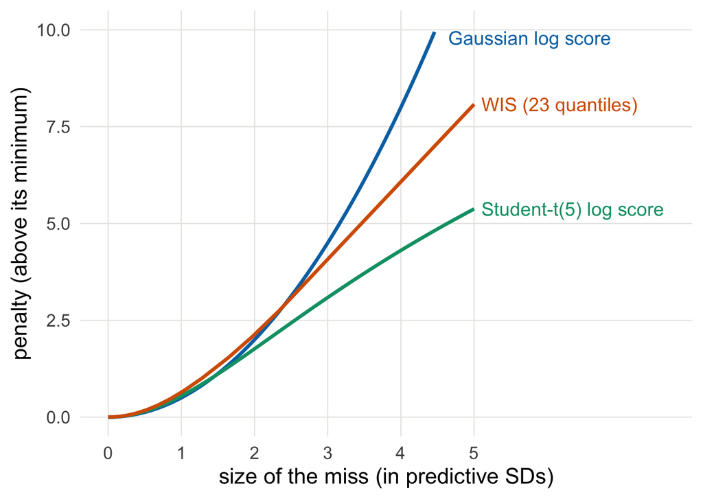

- **Gaussian:** quadratic, so a few big misses dominate the fit
- **WIS:** linear, so big misses count but don’t take over
- **Student-t:** already gentle in the tails, so robustness isn’t the whole story
- The real argument is **focus**: WIS rewards the *quantiles* we actually submit

Development tests: WIS fitting beat likelihood fitting by ~1–2% held-out WIS, more at longer horizons.

## The one knob without a right answer: $w$

$$\pi_{\text{WIS}}(\theta\mid y) \;\propto\; \exp\Big(-\,w\sum_i \text{WIS}(F_\theta, y_i)\Big)\,\pi(\theta)$$

- Scaling the loss by $w$ makes the posterior **narrower or wider**. The loss has no natural units.
- Ours: a cheap plug-in rule. Choose $w$ so the WIS term is about **2×** the size of a Gaussian log-likelihood at an OLS fit.
- FBP proposes principled rules. Ours resembles one of them, except for the ×2 (see appendix).
- In practice the data overwhelm the prior here, so $w$ mostly affects **parameter** uncertainty, not forecast intervals.

# The model

## Data → a well-behaved scale

$$\text{rate}_{\ell t} = \frac{y_{\ell t}}{\text{pop}_\ell}\times 10^5,
\qquad
r_{\ell t} = (\text{rate}_{\ell t} + 0.01)^{1/4},
\qquad
z_{\ell t} = \frac{r_{\ell t}}{q_{95,\ell}} - \bar z_\ell$$

**Why the fourth root?**

- A power transform $x^\lambda$ (Box and Cox 1964): $\lambda=1$ leaves the data alone, $\lambda=\tfrac12$ stabilizes Poisson variance, and $\lambda\to0$ is the log.
- $\lambda=\tfrac14$ compresses big peaks, but less than the log does.
- The model’s dynamics are *fit* on this scale, so the choice changes the fitted model, not just the reporting.

**Evidence:** two models identical except for the transform:

|  | log1p fit | fourth-root fit |
| --- | --- | --- |
| mean WIS (counts) | 148.4 | **137.4** |
| mean WIS (log scale) | 0.360 | **0.335** |

The fourth root wins *even on the log scale*, where log1p should have the edge. It’s also the transform the production SARIX AR models use.

## Mean structure: a pooled seasonal AR(6)

$$z_{\ell t} = \mu_{0\ell} + S(t) + \sum_{j=1}^{6}\phi_j\big(z_{\ell,t-j} - \mu_{0\ell} - S(t-j)\big) + \sigma_\ell\, u_{\ell t},
\qquad u_{\ell t}\sim t_{5}$$

$$S(t) = \sum_{k=1}^{2}\Big[a_k \sin\tfrac{2\pi k\,\text{doy}(t)}{365.25} + b_k \cos\tfrac{2\pi k\,\text{doy}(t)}{365.25}\Big]$$

**Shared across all 53 locations**

- AR coefficients $\phi_1,\dots,\phi_6$
- seasonal curve $a_1, b_1, a_2, b_2$

**Per location**

- level $\mu_{0\ell}$
- noise scale $\sigma_\ell$

Pooling lets small, noisy states borrow the shape of the season from everyone else. The Student-t noise ($\nu=5$) allows occasional big jumps.

## Priors

$$\mu_{0\ell}\sim N(0,\,0.1^2)
\qquad
\sigma_\ell\sim \text{HalfCauchy}(1)$$

$$\phi_j\sim N(0,\,\theta_{sd}^2),\quad \theta_{sd}\sim\text{HalfCauchy}(1)$$

$$a_k,b_k\sim N(0,\,\beta_{sd}^2),\quad \beta_{sd}\sim\text{HalfCauchy}(1)$$

- The hyperpriors **learn** how big $\phi$ and the seasonal terms should be. This mirrors the production SARIX models.
- Honest finding: making the priors adaptive barely changed WIS (75.0 vs. 74.9 on a spot check).
- Why: 53–193 weeks × 53 locations of data, depending on the date. The loss term **dominates the prior**.

## Software and fitting

```python
mu = build_pooled_mean(phi, fourier, mu0, ...)

if objective == "likelihood":
    pm.StudentT("y_obs", nu=5, mu=mu,
                sigma=sigma_obs, observed=y)
elif objective == "wis":
    loss = studentt_wis_loss(mu, sigma_obs,
                             5, y, ALPHA, K)
    pm.Potential("wis", -w * loss)

idata = pm.sample(2000, tune=2000,
                  target_accept=0.99)
```

Same priors, same mean, same sampler. One branch swaps the likelihood for the loss.

- **Forecast:** draw parameters → simulate the AR forward 1–4 weeks with fresh t noise → take quantiles → back-transform.
- **PyMC / PyTensor** (Abril-Pla et al. 2023). `pm.Potential` adds *any* differentiable term to the log posterior.
- **NUTS** (Hoffman and Gelman 2014): MCMC that uses gradients to make long, efficient moves.
  - It needs $\partial\,\text{loss}/\partial\theta$, so $\nu$ is **fixed at 5**: there’s no gradient of the t quantile function with respect to $\nu$.
  - `target_accept = 0.99`: small, careful steps for a tricky posterior. Slower, but no divergences.

## How we got here

| Step | Change | What we learned |
| --- | --- | --- |
| WISAR6 | WIS-loss AR(6)+Fourier on log1p | the idea works |
| `_fourthroot` | log1p → fourth root | mean WIS 148.4 → **137.4** |
| `_adaptive` | learned prior scales | 74.9 → 75.0: **priors weren’t the bottleneck** |
| `_adaptive_diff` | differencing + t noise | ✗ 75.0 → 100.5: drift compounds over horizons |
| **`_adaptive_t`** | t noise alone, no differencing | ✓ 75.0 → **73.8**, better on all 5 dates |

Each step changed one thing and was kept only if it helped. Numbers are mean WIS (lower is better). The fourth-root row uses about 50 reference dates (Oct 2023 – May 2025). The rows below it use a 5-date spot check (rising, peak, falling, post-peak, off-season), each compared with the model it modified.

Context: on these 5 dates AR6_fourierP_thetaP scored 62.6 (counts). Over all 80 dates, the final WISAR6 is about even with it on the log scale (0.356 vs. 0.352) and trails on counts (145.0 vs. 131.7); see the Scorecard.

## WISAR6 on one page

**1 · Transform** (per location $\ell$, week $t$)
$$z_{\ell t} = \frac{(\text{rate}_{\ell t} + 0.01)^{1/4}}{q_{95,\ell}} - \bar z_\ell,
\qquad \text{rate} = \frac{y}{\text{pop}}\times10^5$$

**2 · Mean: pooled seasonal AR(6)**
$$\mu_{\ell t} = \mu_{0\ell} + S(t) + \sum_{j=1}^{6}\phi_j\big(z_{\ell,t-j} - \mu_{0\ell} - S(t-j)\big)$$
$$S(t)=\textstyle\sum_{k=1}^{2} a_k\sin\frac{2\pi k\,\text{doy}}{365.25} + b_k\cos\frac{2\pi k\,\text{doy}}{365.25}$$
Shared: $\phi$, $a_k$, $b_k$. Per location: $\mu_{0\ell}$, $\sigma_\ell$.

**3 · Predictive (one step ahead)**
$$z_{\ell t}\mid\mathcal F_{t-1} \;\sim\; \mu_{\ell t} + \sigma_\ell\, t_{\nu},\qquad \nu = 5 \text{ (fixed)}$$

**4 · Priors**
$$\mu_{0\ell}\sim N(0,0.1^2),\quad \sigma_\ell\sim \text{HC}(1)$$
$$\phi_j\sim N(0,\theta_{sd}^2),\quad a_k,b_k\sim N(0,\beta_{sd}^2),\quad
\theta_{sd},\beta_{sd}\sim\text{HC}(1)$$
HC = HalfCauchy. The hyperpriors learn the scale of $\phi$ and of the seasonal terms.

**5 · Objective: WIS Gibbs posterior** (FBP with $S=-\text{WIS}$)
$$\pi(\theta\mid y) \;\propto\; \exp\Big(-\,w \sum_{\ell,t}\text{WIS}\big(F_{\theta,\ell t},\, z_{\ell t}\big)\Big)\,\pi(\theta)$$
WIS at the hub’s 23 quantile levels, using the Student-t quantiles of step 3. Weight: $w = 2\,|\log L_{\text{OLS}}| \,/\, \text{WIS}_{\text{OLS}}$.

**6 · Fit**

- PyMC: the loss enters via `pm.Potential`; same priors and mean as a likelihood fit
- NUTS: 2 chains × 2,000 draws (2,000 tuning), target accept 0.99
- All 53 locations fit jointly each week

**7 · Forecast**

- For each posterior draw: simulate the AR(6) forward 4 weeks with fresh $t_5$ noise
- Pool the draws → 23 quantiles per location and horizon → invert step 1 to get counts
- Submitted alone, and as half of UMass-flusion (with GBQR)

**Why each piece:** fourth root beat log1p; pooling shares the season’s shape; t noise allows jumps; WIS focuses the fit on the submitted quantiles.

# Forecasts

## 2023–24 season

[interactive chart not shown]

## 2024–25 season

[interactive chart not shown]

## 2025–26 season

[interactive chart not shown]

## 2025–26 snapshots: early, peak, late

- Early (rising, WA)
- Peak
- Late (falling shoulder)

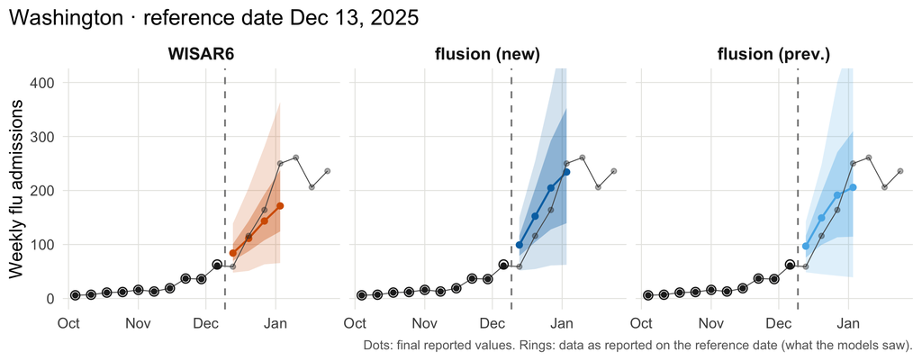

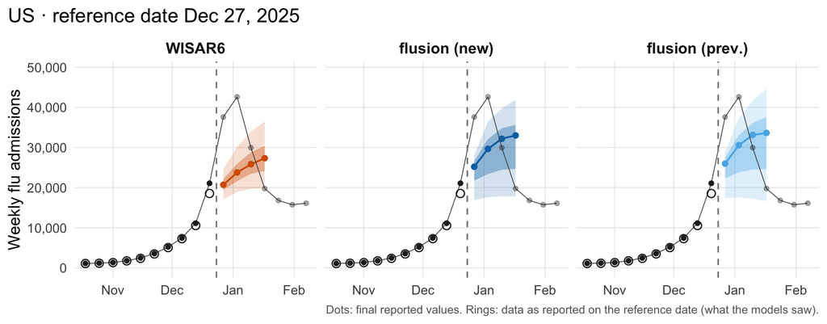

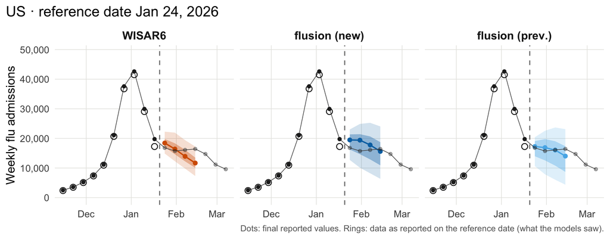

Static backup for the explorer. The falling shoulder is WISAR6’s known weak spot.

## Scorecard

**Standalone AR models** (80 reference dates, 2023–26)

|  | WISAR6 | AR6_fourierP | AR6_pooled |
| --- | --- | --- | --- |
| Mean WIS, counts | 145.0 | **131.7** | 146.0 |
| Mean WIS, log scale | 0.356 | **0.352** | 0.400 |
| Pairwise ratio vs. AR6_pooled, counts | 0.993 | **0.902** | 1 |
| Pairwise ratio vs. AR6_pooled, log | 0.890 | **0.882** | 1 |

Pairwise ratio = ratio of mean WIS on matched forecasts, the building block of the hub’s relative WIS. On counts, a few big states on bad weeks dominate.

**Inside the ensemble** (spatial GBQR + AR partner, 80 dates)

|  | + WISAR6 (new flusion) | + AR6_fourierP |
| --- | --- | --- |
| Mean WIS, counts | 119.0 | **116.0** |
| Mean WIS, log scale | **0.298** | 0.303 |
| Ratio, counts | 1.026 | 1 |
| Ratio, log | **0.983** | 1 |

WISAR6 is a slightly better partner on the log scale and slightly worse on counts. Caveat: in a 2025–26 check, GBQR *alone* beat every equal-weight GBQR+AR ensemble. Open question: weighting.

## Status and next steps

- **Weak spot:** post-peak falling shoulders. The AR recursion overshoots declines over 2–4 weeks.
- **Multi-horizon focus:** score 1–4-step-ahead forecasts during fitting, not just 1-step, as FBP did for M4 (Loaiza-Maya, Martin, and Frazier 2021).
- **Principled $w$:** test FBP’s rules against the ×2 heuristic.
- **Flexibility:** more Fourier terms ($K=3,4$); a skewed noise distribution for the remaining low bias.
- **Ensemble weights:** unequal GBQR/WISAR6 weights instead of 50/50.

## References

Abril-Pla, Oriol, Virgile Andreani, Colin Carroll, et al. 2023. “PyMC: A Modern, and Comprehensive Probabilistic Programming Framework in Python.” *PeerJ Computer Science* 9: e1516.

Bissiri, P. G., C. C. Holmes, and S. G. Walker. 2016. “A General Framework for Updating Belief Distributions.” *Journal of the Royal Statistical Society: Series B* 78 (5): 1103–30.

Bosse, Nikos I., Sam Abbott, Anne Cori, Edwin van Leeuwen, Johannes Bracher, and Sebastian Funk. 2023. “Scoring Epidemiological Forecasts on Transformed Scales.” *PLOS Computational Biology* 19 (8): e1011393.

Box, G. E. P., and D. R. Cox. 1964. “An Analysis of Transformations.” *Journal of the Royal Statistical Society: Series B* 26 (2): 211–52.

Bracher, Johannes, Evan L. Ray, Tilmann Gneiting, and Nicholas G. Reich. 2021. “Evaluating Epidemic Forecasts in an Interval Format.” *PLOS Computational Biology* 17 (2): e1008618.

CDC NHSN. 2025. “Weekly Hospital Respiratory Data (HRD) Metrics by Jurisdiction, National Healthcare Safety Network (NHSN).” data.cdc.gov. https://data.cdc.gov/Public-Health-Surveillance/Weekly-Hospital-Respiratory-Data-HRD-Metrics-by-Ju/mpgq-jmmr.

Gneiting, Tilmann, and Adrian E. Raftery. 2007. “Strictly Proper Scoring Rules, Prediction, and Estimation.” *Journal of the American Statistical Association* 102 (477): 359–78.

Hoffman, Matthew D., and Andrew Gelman. 2014. “The No-U-Turn Sampler: Adaptively Setting Path Lengths in Hamiltonian Monte Carlo.” *Journal of Machine Learning Research* 15: 1593–623.

Loaiza-Maya, Rubén, Gael M. Martin, and David T. Frazier. 2021. “Focused Bayesian Prediction.” *Journal of Applied Econometrics* 36 (5): 517–43.

Ray, Evan L., Yijin Wang, Russell D. Wolfinger, and Nicholas G. Reich. 2024. “Flusion: Integrating Multiple Data Sources for Accurate Influenza Predictions.” https://arxiv.org/abs/2407.19054.

# Appendix

## FBP theory: concentration and merging

**Lemma 1** (Loaiza-Maya, Martin, and Frazier 2021). If $w_n\to C\in(0,\infty)$, $\Pi_w$ concentrates at rate $1/\sqrt n$ on

$$\theta_* = \arg\max_\theta\; \lim_{n} \mathbb{E}\big[S_n(\theta)/n\big],$$

the most accurate predictive in the class *under the chosen score*, whether or not the truth is in the class.

**Merging (Thm 1).** The FBP posterior-mean predictive and the plug-in predictive at $\hat\theta = \arg\max_\theta S_n(\theta)$ agree asymptotically in total variation.

- Implication: a point-estimate WIS fit (e.g. L-BFGS) plus simulation should forecast nearly the same as NUTS. That’s a cheap check, and a possible speed-up.
- Relation to Bissiri, Holmes, and Walker (2016): they supply the general loss-based update; FBP specializes it to proper scores on time-series predictives and proves results for that setting.

## What is “the class” for WISAR6?

All one-step-ahead predictives the model can produce, on the scaled fourth-root scale $z$:

$$\mathcal{P}_\Theta=\Big\{\,z_{\ell,t}\mid z_{\ell,1:t-1}\;\sim\;\mu_{\ell,t}(\theta)+\sigma_\ell\,t_5\;:\;\theta\in\Theta\Big\}$$
$$\mu_{\ell,t}(\theta)=\mu_{0\ell}+S(t)+\textstyle\sum_{j=1}^{6}\phi_j\big(z_{\ell,t-j}-\mu_{0\ell}-S(t-j)\big)$$

| Parameters | Count | Pooling |
| --- | --- | --- |
| $\phi_1,\dots,\phi_6$ (AR) | 6 | shared across 53 locations |
| Fourier coefficients ($K=2$) | 4 | shared |
| $\mu_{0\ell}$ (level), $\sigma_\ell$ (scale) | 53 + 53 | per location |

Hyperparameters shape the prior but don’t enlarge the class. FBP targets $\theta_*=\arg\min_\theta \mathbb{E}[\text{WIS}(p_\theta,z_t)]$; a $t_5$ likelihood would target the KL-closest member instead.

**Not in the class:** learned tail weight ($\nu$ fixed), time-varying volatility or growth terms, cross-location dependence beyond shared $\phi$ and $S$, and multi-step predictives (h = 0–3 are simulated from one-step members).

## Why the lags subtract $S(t-j)$

The AR term acts on **deviations from the expected seasonal level**, not on raw values:

$$\text{dev}_{\ell,t-j} = z_{\ell,t-j} - \underbrace{\big(\mu_{0\ell} + S(t-j)\big)}_{\text{expected level for week } t-j}$$

$$z_{\ell t} = \underbrace{\mu_{0\ell} + S(t)}_{\text{where a typical season is}} + \underbrace{\textstyle\sum_{j}\phi_j\,\text{dev}_{\ell,t-j}}_{\text{how far off we are, and how much persists}} + \sigma_\ell u_{\ell t}$$

- Each lag subtracts the curve **at its own week** $t-j$, so every deviation is measured against the right baseline.
- With raw lags $\sum_j\phi_j z_{\ell,t-j}$, the seasonal pattern would be counted twice: once via $S(t)$ and again inside the lags, which already carry last week’s season.
- With stable $\phi$, deviations decay, so longer-horizon forecasts **drift back toward $\mu_{0\ell}+S(t)$**. This is part of why forecasts lag behind sharp rises and falls.
- It is an AR model on deseasonalized data, but the seasonal curve and the AR coefficients are **estimated jointly**, not removed in a separate first step.

## Choosing $w$

**FBP, CRPS case:** match the log-score posterior’s rate of updating

$$w_n=\frac{\mathbb{E}_{\pi(\theta\mid y)}\big[\sum_t S_{\text{LS}}\big]}{\mathbb{E}_{\pi(\theta\mid y)}\big[\sum_t S_{\text{CRPS}}\big]}
\quad\text{(averaged over exact-Bayes draws)}$$

**FBP, interval-score (M4) case:** $\;w_n = \dfrac{n\,d_\theta}{2\,S_n(P_{\hat\theta})}$, where $\hat\theta$ is the MLE and $d_\theta$ is the number of parameters.

**Ours:** fit OLS on the same design, then

$$w = 2\times\frac{\big|\sum_i \log \phi(y_i;\hat\mu_i,\hat\sigma_{\ell(i)})\big|}{\sum_i \text{WIS}_{\text{Gauss}}(\hat\mu_i,\hat\sigma_{\ell(i)}, y_i)}$$

- This resembles the first rule, evaluated at one plug-in point instead of averaged over draws.
- The **×2** has no FBP counterpart. It makes the posterior about 2× more concentrated.

## Fine print

- **Which scale is focused?** WIS is computed on the scaled fourth-root scale $z$, but the hub scores counts and $\log(x+1)$. Quantiles carry over (they’re equivariant under monotone maps); WIS *magnitudes* don’t. So the fit is focused on a proxy for the score we’re judged by.
- **Pooling:** WIS is summed over 53 locations with **one** $w$ (FBP uses one per series). The $q_{95}$ scaling roughly equalizes the locations.
- **Why not fit $\log(\text{WIS})$?** It isn’t a proper scoring rule. The right way to target the log-scale metric is to transform the data and then apply WIS.
- **Differencing:** forecasts are cumulative sums of predicted steps, so drift error compounds. Overprediction grew 19 → 28 → 50 → 67 across horizons 0–3 on one off-season date.
- **One-step vs. multi-step:** the fit scores 1-step-ahead predictives, while the hub scores 1–4 steps ahead.

## Data note: point-in-time training data

Backtests must train only on the data that was available on each reference date.

- **What happened:** an earlier version of WISAR6 read the FluSight hub’s dated target-data snapshots, which skip some weeks. On 9 of the 80 backtest dates it trained one week short and had to simulate the missing week.
- **The fix:** WISAR6 now reads the same NHSN releases as GBQR and AR6 (`iddata`, as of the reference date), with no skipped weeks. **All results in this talk use the corrected runs.**
- **Training history:** the old snapshots went back to Feb 2022. The corrected runs start Sep 2022 for 2023–24 dates (HHS-era data) and Aug 2022 after that (NHSN data), so every date changed slightly.
- **Effect on WISAR6:** mean WIS on the 9 affected dates improved from 213.9 to 165.9 (counts). Overall it’s about the same: 149.1 → 145.0 on counts, 0.349 → 0.356 on the log scale. 2023–24 is a bit worse, likely because of the shorter history.
- **Submissions** to FluSight were not affected: live runs read the current data file, not the snapshots.